# Ford GoBike System Data Visualization

## by Betizazu Alemu

## Investigation Overview

> In this presentation, I wanted to look at what is the ratio of user types, their usage hourly in a day, and their usage distributed weekday hourly usage

## Dataset Overview

> Ford GoBike System Dataset includes information about individual rides made in a bike-sharing system covering the greater San Francisco Bay area in the month of February, 2019.  
> This data set includes information about individual rides made in a bike-sharing system covering the greater San Francisco Bay area in the year 2019. The data set has been stored as a csv file, it has 12 features and 183412 entries. The features are:
> - duration_min - Ridden time in min
> - start_time - Ride start time
> - end_time - Ride end time
> - start_station_name - Ride start station name
> - end_station_name - Ride end station name
> - bike_id - Ride bike id
> - user_type - User type either Subscriber or Customer
> - member_gender - Member gender
> - bike_share_for_all_trip - If the bike is used for the round trip
> - age - Rider age
> - age - Rider age grouped under the 10s
> - weekday - the name of weekday extracted from start_time feature

## Distribution of User Types

The plot shows almost 90% of the bike users are subscribers.

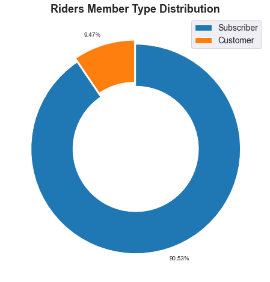

## User Type Vs Ride Duration Distribution

I would like to show what the ride duration distribution look like for each user type. Since there are outliers found in ride duration, I will first visualize the graph without any limitation in the left, and I will draw the limited (i.e., between 0 - 100 min) version of the graph in right side since most of the durations not last more than 100 mins.

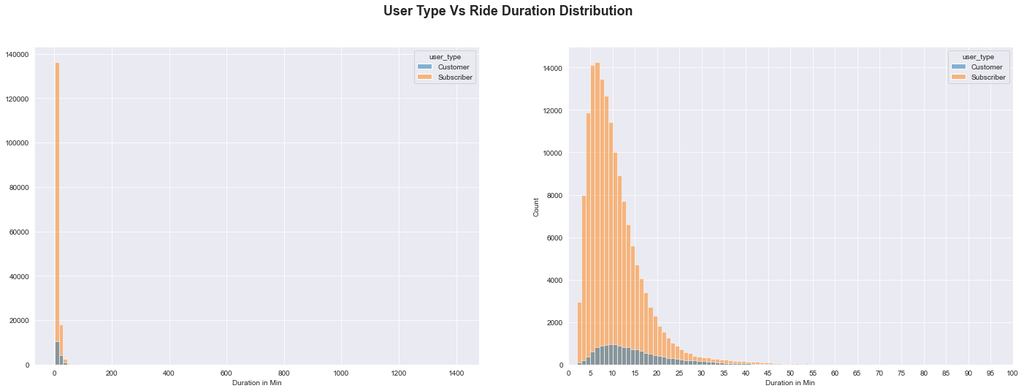

## User Type Vs Hourly Ride Distribution

The following graph shows what the user types ride distribution looks like for each hours in a day.

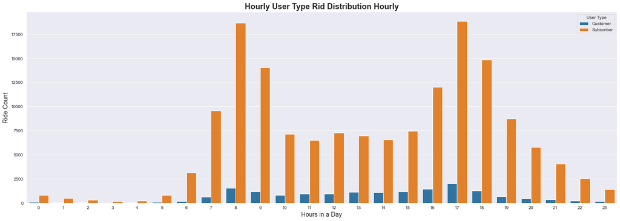

## User Type, Hourly Ride, and Weekday Distribution

The following graph shows which user type ride bikes more frequent at what time during the weekdays.

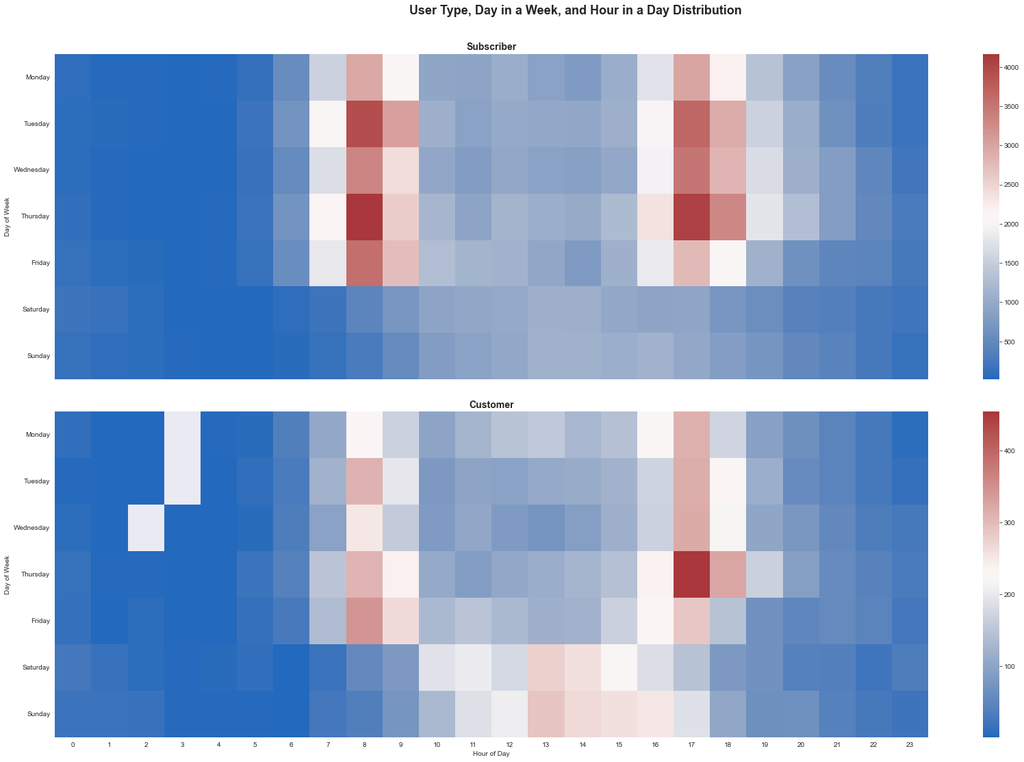